# **Modelo predictor de carros registrados en el RUNT.**

## **Asignatura:**

### Técnicas de aprendizaje estadístico

### Universidad Nacional de Colombia

### Sede Medellín

### Facultad de minas

### 2018-2

## **Profesor:**

### Juan David Ospina Arango

## **Hecho por:**

### Santiago Restrepo Álvarez

### Mateo Zuluaga Giraldo

### Sebastián Ramírez Tamayo

### David Ossa Saldarriaga

### Daniel Restrepo Mejía

### **Introducción:**

El siguiente trabajo gira en torno a crear un modelo predictivo de los automóviles registrados en el RUNT. ¿Cómo se logrará esto?: Más adelante veremos cómo a partir de un archivo que contiene el número de automóviles registrados diariamente en el RUNT desde 2012 hasta 2017, se puede “entrenar” un modelo para predecir los automóviles que se registrarán en un futuro.

### **Entendimiento inicial:**

Todo automóvil que se quiera poner en circulación en el país, debe antes ser registrado en el Registro Único Nacional de Transito(RUNT), con el fin de determinar la propiedad, características y situación jurídica de los vehículos automotores terrestres, este registro se lleva a cabo en los días hábiles y permite principalmente tener un registro completo de todos los automóviles terrestres que circulan sobre el territorio nacional. El RUNT permite conocer las fichas técnicas de homologación, emisiones de gases, entre otros datos de interés. A continuación en el análisis técnico se verá detalladamente el procedimiento empleado para construir el modelo.

### **Análisis técnico**

Después de esta breve contextualización, se dará inicio a la explicación del cómo se construyó el proyecto; inicialmente se nos proporcionó un único archivo plano que contenía todos los registros de los automóviles registrados diariamente en el RUNT, el archivo contiene dos columnas, una de fecha y otra de número de autos registrados, y tiene una fila por cada día comprendido entre el primero (1) de Enero de 2012 y el treinta y uno (31) de Diciembre de 2017, el principal requisito del modelo es que sea entrenado con los datos de 2012 hasta 2016 y usar los datos de 2017 como validación y posteriormente predecir todo el primer semestre del 2018, cabe aclarar que no tenemos los datos reales del 2018, estos sólo los tiene el profesor. Como sólo se tiene una variable, es necesario buscar por cuenta propia otras variables de las que podamos descargar sus registros en este lapso de tiempo y que estas variables mejoren la predicción del modelo; se partió de variables relacionadas con el crecimiento de la economía nacional cómo punto de partida. Las variables que inicialmente elegimos como candidatas para estar en el modelo cómo variables independientes son las siguientes:

- **Mes:**

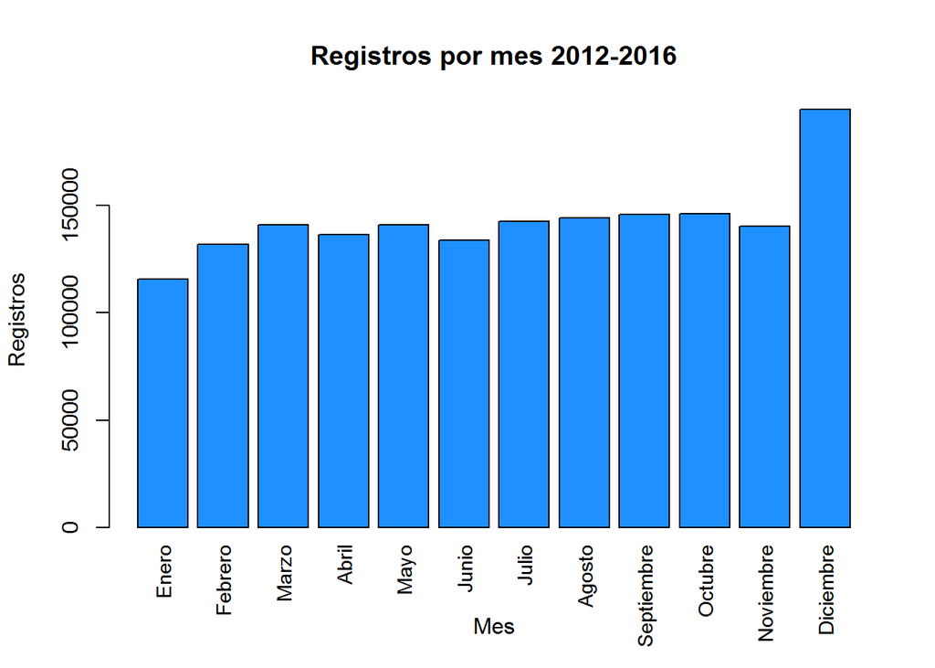

  Se quiso tomar el mes, ya que al hacer el análisis descriptivo a partir de los registros por mes, se pudo ver que había una tendencia a crecer a medida que el año se iba acabando, por esto y porque además es una variable relativamente fácil de calcular, se tomó la decisión de incluirla.
- **Día del mes:** A partir de el entendimiento inicial, se llegó a la suposición de que las personas en las épocas de quincena podrían estar más animadas a comprar un vehículo, también se tuvo en cuenta por facilidad a la hora de obtenerse.
- **Día de la semana:**

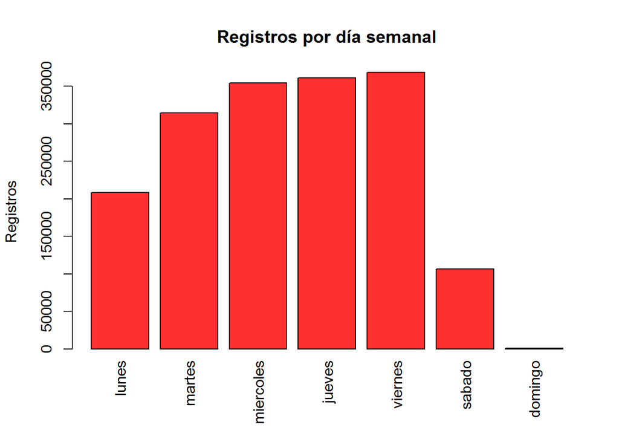

  En el gráfico se puede apreciar que hay más registros a medida que la semana va avanzando y que los fines de semana se reducen mucho los registros, además de que los registros los Domingos son casi nulos (se debe tener en cuenta que en los días festivos no hay registros pero no hay manera de saber qué días son festivos).
- **Año:**

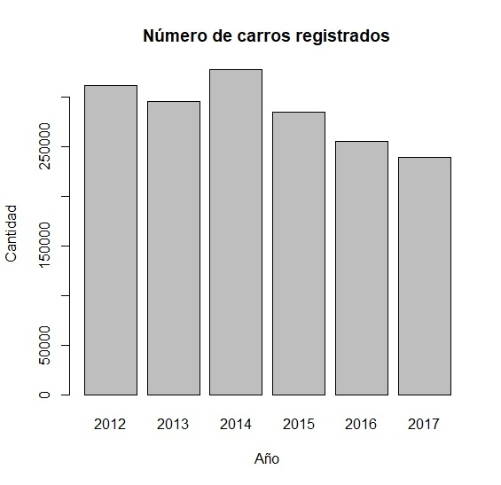

  En el gráfico anterior se logra ver que a medida que los años pasan, la tendencia a registrar carros disminuye, por eso se decidió incluir la variable en el modelo.

### **Ahora las variables relacionadas con la economía:**

- **Popularidad en Colombia de la palabra “carro” según Google Trends.**
- **Tasa representativa del mercado(dólar).**
- **[Tasa de empleo](https://www.dane.gov.co/index.php/estadisticas-por-tema/mercado-laboral/empleo-y-desempleo%22%3E)**
- **[Tasa de desempleo](https://www.dane.gov.co/index.php/estadisticas-por-tema/mercado-laboral/empleo-y-desempleo%22%3E)**
- **[Índice de precio al consumidor](http://www.banrep.gov.co/es/indice-precios-consumidor-ipc%22%3E)**
- **[Precio promedio de el barril de petróleo BRENT](https://es.wikipedia.org/wiki/Petr%C3%B3leo_Brent%22%3E)**
- **[Salario mínimo](http://www.salariominimocolombia.net/historico/%22%3E)**
- **[DTF](https://www.eltiempo.com/archivo/documento/MAM-541703%22%3E)**
- **[Índice de confianza del consumidor](https://www.fedesarrollo.org.co/encuestas/consumidor-eoc%22%3E)**

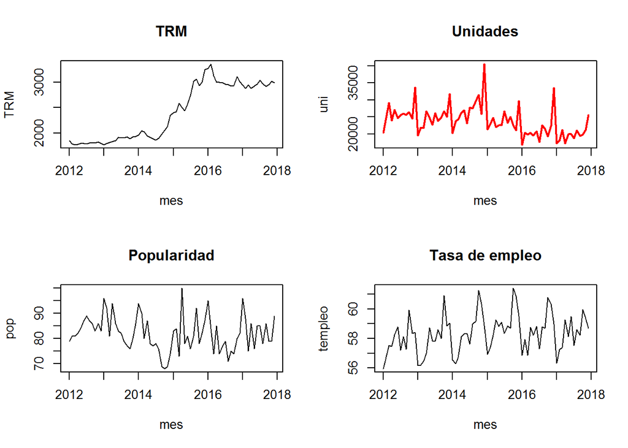

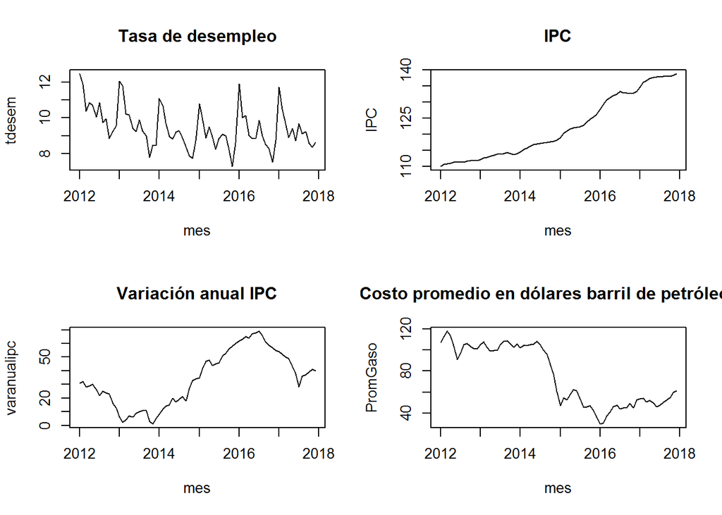

  Al elaborar diagramas de líneas se logra ver la tendencia anteriormente mencionada de que en Diciembre hay más registros, al haber más registros se refiere a que hay más compras de carros, por lo tanto: La economía va a tener un movimiento mayor. Se logra ver que las variables tales cómo: La popularidad, tasa de empleo, tasa de desempleo y los carros registrados poseen picos muy pronunciados a final de cada año. Se logra notar también que a medida que la tasa representativa del mercado ha subido, la cantidad de carros registrados baja; igualmente el barril de petróleo. La variación anual de el IPC ha dado a notar que la inflación ha crecido, eso también daría una explicación a la reducción de los registros de los carros.

  Nota: los datos se obtienen de la página del Banco de la República[3].

### **Evaluación de retraso de las variables(lag).**

  Antes de comenzar a analizar los modelos, se debe tener en cuenta que variables cómo el dólar(TRM) o la popularidad pueden influir a futuro(variable con retraso) con las unidades de vehículos registradas.

  **Para la TRM:**

  A partir de el comando “ccf” de R que permite calcular la correlación cruzada entre variables específicas, se obtiene lo siguiente:

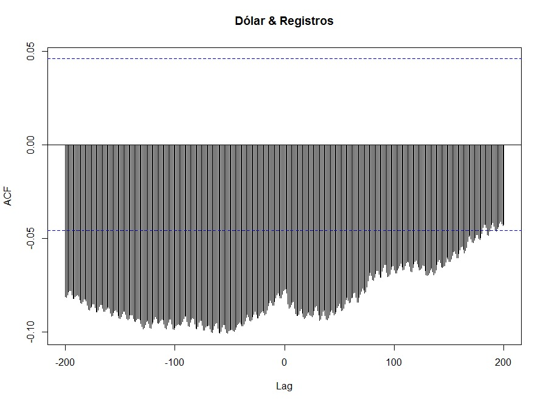

  Se puede ver que el coeficiente de correlación más influyente, se encuentra aproximadamente 2 meses atrás pero se interpreta que el coeficiente no es muy bueno ya que es muy cercano a 0. Se logra ver que hay una relación inversa muy leve en que a medida que el dólar sube, los registros de autos bajan.

  **Para la popularidad:**

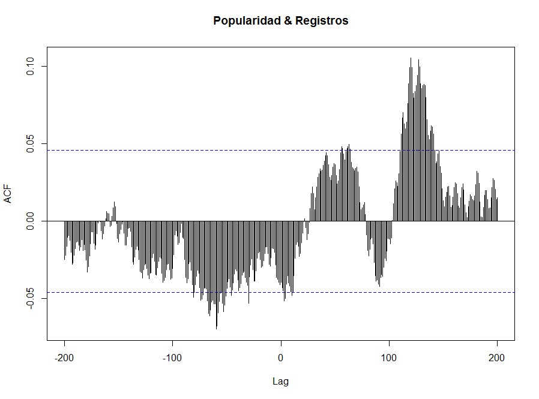

  Ambas variables son importantes en la economía y en las ganas de un consumidor a la hora de comprar un vehículo (registro), pero al ser variables con tan poco enlace respecto a la correlación en el pasado, no es muy buena idea conservarlas.

### **Creación y selección de el modelo de predicción.**

  Inicialmente se intentó hacer una regresión lineal clásica con las variables anteriormente mencionadas(exceptuando año y día del mes), la cuál dio cómo resultado el siguiente modelo:

  ```
  ##
  ## Call:
  ## lm(formula = Unidades ~ mes + dia + pop + templeo + tdesem +
  ##     IPC + varanualipc + Promgaso + salmini + detf + iconf)
  ##
  ## Residuals:
  ##      Min       1Q   Median       3Q      Max
  ## -1396.35  -115.27     9.02   119.13  2404.64
  ##
  ## Coefficients:
  ##                Estimate Std. Error t value Pr(>|t|)
  ## (Intercept)   3.036e+03  1.139e+03   2.666  0.00775 **
  ## mes           3.285e+01  5.622e+00   5.843 6.08e-09 ***
  ## diajueves     1.181e+03  2.815e+01  41.946  < 2e-16 ***
  ## dialunes      6.882e+02  2.814e+01  24.456  < 2e-16 ***
  ## diamartes     1.028e+03  2.814e+01  36.520  < 2e-16 ***
  ## diamiercoles  1.167e+03  2.815e+01  41.471  < 2e-16 ***
  ## diasabado     3.555e+02  2.814e+01  12.632  < 2e-16 ***
  ## diaviernes    1.215e+03  2.814e+01  43.184  < 2e-16 ***
  ## pop          -2.676e+00  1.455e+00  -1.839  0.06602 .
  ## templeo      -2.698e+01  1.344e+01  -2.007  0.04486 *
  ## tdesem       -1.556e+00  2.015e+01  -0.077  0.93845
  ## IPC          -2.452e+01  1.459e+01  -1.681  0.09300 .
  ## varanualipc  -1.489e+00  1.625e+01  -0.092  0.92699
  ## Promgaso     -6.844e-01  8.102e-01  -0.845  0.39841
  ## salmini       2.596e-03  2.083e-03   1.246  0.21284
  ## detf         -8.659e+00  2.032e+01  -0.426  0.67004
  ## iconf        -6.342e-01  6.271e-01  -1.011  0.31199
  ## ---
  ## Signif. codes:  0 '***' 0.001 '**' 0.01 '*' 0.05 '.' 0.1 ' ' 1
  ##
  ## Residual standard error: 321.5 on 1810 degrees of freedom
  ## Multiple R-squared:  0.664,  Adjusted R-squared:  0.661
  ## F-statistic: 223.5 on 16 and 1810 DF,  p-value: < 2.2e-16
  ```

  Se obtuvo un $R^2$ de 66% aproximadamente para este modelo.

  Al aplicar selección de variable hacia atrás, se obtuvo el siguiente modelo:

  ```
  ##
  ## Call:
  ## lm(formula = Unidades ~ mes + dia + pop + templeo + IPC + salmini)
  ##
  ## Residuals:
  ##      Min       1Q   Median       3Q      Max
  ## -1387.52  -116.38    13.22   120.57  2398.63
  ##
  ## Coefficients:
  ##                Estimate Std. Error t value Pr(>|t|)
  ## (Intercept)   2.630e+03  5.499e+02   4.783 1.86e-06 ***
  ## mes           3.458e+01  4.041e+00   8.556  < 2e-16 ***
  ## diajueves     1.180e+03  2.812e+01  41.973  < 2e-16 ***
  ## dialunes      6.883e+02  2.812e+01  24.475  < 2e-16 ***
  ## diamartes     1.028e+03  2.812e+01  36.545  < 2e-16 ***
  ## diamiercoles  1.167e+03  2.812e+01  41.495  < 2e-16 ***
  ## diasabado     3.556e+02  2.812e+01  12.646  < 2e-16 ***
  ## diaviernes    1.215e+03  2.812e+01  43.218  < 2e-16 ***
  ## pop          -2.553e+00  1.235e+00  -2.067 0.038920 *
  ## templeo      -2.682e+01  9.372e+00  -2.861 0.004266 **
  ## IPC          -2.799e+01  5.962e+00  -4.696 2.86e-06 ***
  ## salmini       3.632e-03  1.041e-03   3.489 0.000496 ***
  ## ---
  ## Signif. codes:  0 '***' 0.001 '**' 0.01 '*' 0.05 '.' 0.1 ' ' 1
  ##
  ## Residual standard error: 321.2 on 1815 degrees of freedom
  ## Multiple R-squared:  0.6636, Adjusted R-squared:  0.6615
  ## F-statistic: 325.5 on 11 and 1815 DF,  p-value: < 2.2e-16
  ```

  Cómo se puede ver, el $R^2$ es casi el mismo y se redujo el modelo a sólo unas pocas variables, las cuales son: Día de la semana, mes, popularidad, IPC, tasa de empleo y salario mínimo.

  ```
  ##
  ## Call:
  ## glm(formula = Unidades ~ mes + dia + templeo + tdesem + IPC +
  ##     Promgaso + salmini + detf + iconf + dmes, family = poisson)
  ##
  ## Deviance Residuals:
  ##     Min       1Q   Median       3Q      Max
  ## -58.171   -3.256   -0.497    4.326   47.379
  ##
  ## Coefficients:
  ##                Estimate Std. Error z value Pr(>|z|)
  ## (Intercept)   4.590e+00  1.270e-01  36.154  < 2e-16 ***
  ## mes           3.785e-02  5.382e-04  70.328  < 2e-16 ***
  ## diajueves     5.899e+00  3.442e-02 171.360  < 2e-16 ***
  ## dialunes      5.362e+00  3.446e-02 155.615  < 2e-16 ***
  ## diamartes     5.762e+00  3.443e-02 167.352  < 2e-16 ***
  ## diamiercoles  5.888e+00  3.442e-02 171.047  < 2e-16 ***
  ## diasabado     4.703e+00  3.453e-02 136.197  < 2e-16 ***
  ## diaviernes    5.928e+00  3.442e-02 172.210  < 2e-16 ***
  ## templeo      -3.507e-02  1.466e-03 -23.929  < 2e-16 ***
  ## tdesem       -2.016e-02  2.154e-03  -9.357  < 2e-16 ***
  ## IPC          -2.846e-02  1.281e-03 -22.219  < 2e-16 ***
  ## Promgaso     -4.695e-04  7.068e-05  -6.642 3.10e-11 ***
  ## salmini       2.966e-06  1.949e-07  15.213  < 2e-16 ***
  ## detf         -1.056e-02  2.135e-03  -4.945 7.62e-07 ***
  ## iconf        -8.509e-04  6.588e-05 -12.916  < 2e-16 ***
  ## dmes          1.506e-02  9.405e-05 160.109  < 2e-16 ***
  ## ---
  ## Signif. codes:  0 '***' 0.001 '**' 0.01 '*' 0.05 '.' 0.1 ' ' 1
  ##
  ## (Dispersion parameter for poisson family taken to be 1)
  ##
  ##     Null deviance: 913454  on 1826  degrees of freedom
  ## Residual deviance: 231047  on 1811  degrees of freedom
  ## AIC: 244215
  ##
  ## Number of Fisher Scoring iterations: 6
  ```

  ```
  ## [1] 0.7470623
  ```

  Se obtiene un $R^2$ de el 74%, el cuál es mucho mejor respecto a los modelos lineales clásicos usados anteriormente.

  Ahora hay otro problema para abarcar: ¿Son las variables a usar realmente proyectables? ¿Qué tan confiables son -si es que existen- estas proyecciones?

  Para dar solución a esta problemática, se separan las variables en dos grupos: Variables sin necesidad de proyeccion (día del mes, año, mes, día de la semana) y las variables a proyectar(TRM,IPC,tasa de empleo, tasa de desempleo, índice de confianza al consumidor, precio de el barril de petróleo, salario mínimo, popularidad y variación anual del IPC).

  Se decide entonces probar con un modelo de regresión lineal generalizado Poisson solamente con las variables sin necesidad de proyección:

  ```
  ##
  ## Call:
  ## glm(formula = Unidades ~ mes + dia + ano + dmes, family = poisson)
  ##
  ## Deviance Residuals:
  ##     Min       1Q   Median       3Q      Max
  ## -56.248   -3.792   -0.464    4.815   46.111
  ##
  ## Coefficients:
  ##                Estimate Std. Error z value Pr(>|z|)
  ## (Intercept)   8.706e+01  1.174e+00   74.14   <2e-16 ***
  ## mes           2.460e-02  2.393e-04  102.78   <2e-16 ***
  ## diajueves     5.898e+00  3.442e-02  171.32   <2e-16 ***
  ## dialunes      5.362e+00  3.446e-02  155.60   <2e-16 ***
  ## diamartes     5.761e+00  3.443e-02  167.33   <2e-16 ***
  ## diamiercoles  5.887e+00  3.443e-02  171.00   <2e-16 ***
  ## diasabado     4.703e+00  3.453e-02  136.19   <2e-16 ***
  ## diaviernes    5.928e+00  3.442e-02  172.20   <2e-16 ***
  ## ano          -4.285e-02  5.828e-04  -73.51   <2e-16 ***
  ## dmes          1.505e-02  9.401e-05  160.08   <2e-16 ***
  ## ---
  ## Signif. codes:  0 '***' 0.001 '**' 0.01 '*' 0.05 '.' 0.1 ' ' 1
  ##
  ## (Dispersion parameter for poisson family taken to be 1)
  ##
  ##     Null deviance: 913454  on 1826  degrees of freedom
  ## Residual deviance: 235588  on 1817  degrees of freedom
  ## AIC: 248744
  ##
  ## Number of Fisher Scoring iterations: 6
  ```

  ```
  ## [1] 0.742091
  ```

  Cómo se puede ver, nuestro $R^2$ se conservó de una manera impresionante, dando a entender que las variables que más influyen en nuestro modelo son las que carecen de la necesidad de proyección, tener un modelo así posee muchas ventajas, una de ellas es que se puede proyectar con mayor facilidad y sin restricciones a futuro -eso si- se debe tener en cuenta que el entrenamiento de el modelo sólo tuvo en cuenta lo comprendido entre 2012 y 2016 y que esas tendencias pueden desaparecer a medida que el tiempo pase.

  **Validación de los datos**

  Se procede entonces a obtener la validación de el modelo a partir de los datos de 2017.

  Los datos poseen el siguiente aspecto:

  ```
  ##             fit
  ## 1828   1.966999
  ## 1829 425.524876
  ## 1830 644.261488
  ## 1831 741.298794
  ## 1832 760.850812
  ## 1833 795.861971
  ```

  A partir de las tantas fórmulas para calcular explicatividad de variables, se procede a usar la siguiente para el cálculo de el $pseudoR^2$.
  $$R^2=1-\frac{\sum_{i=1}^{n} (Y_i-\hat{Y_i})^2}{\sum_{i=1}^{n}(Y_i-\bar{Y})^2}$$

  ```
  ## [1] 0.6295267
  ```

  Se obtiene un $R^2$ de validación de aproximadamente el 63% para los datos de el año 2017.

### **Enfoque.**

  Después de todo este esfuerzo para construir este modelo que acabamos de ver, surgirá la pregunta: ¿Para qué todo esto? Pues bueno, el proyecto podría no tener un enfoque único, ya que este modelo podría ser de mucha utilidad para el estado o empresas privadas, a continuación veremos tres ejemplos prácticos.  
  En primer lugar y el ejemplo más trivial estaría en la contratación de personal, ya que el número de registros de vehículos en un día, se traduce en personas haciendo fila, así que este modelo serviría para hacer una contratación dinámica, es decir: Que se contrate más personal en los meses del año en los que más autos se registran para agilizar la atención y así mismo contratar menos personal en los meses con menos registros, para así ahorrar recursos.  
  Como segundo ejemplo, está la infraestructura vial y políticas de movilidad, ya que el modelo le serviría al estado para predecir el crecimiento del parque automotor, para implementar políticas de movilidad o construir infraestructura.  
  Como último ejemplo, tenemos al sector privado, especificamente a las compañías que fabrican y venden autos, ya que estas sabiendo la porción de mercado que tienen frente a la competencia, antes de inundar el mercado con más autos de los que van a vender, podrían predecir estas cifras, para no incurrir en perdidas por tener demasiadas existencias de vehículos en venta. También puede servir a la hora de implementar políticas de expansión.

### **Aplicación.**

  Con el objetivo de mostrar el resultado, se creó una aplicación web, a la que se puede acceder en el siguiente [enlace](https://sarestrepoal.shinyapps.io/RegistrosRUNT/), su funcionamiento es muy secillo, únicamente se debe seleccionar el rango de fechas que se quiere predecir, y la aplicación nos devolverá una lista de las predicciones diarias comprendidas en este rango, además hay un botón para generar un pequeño resumen descriptivo.  
  *También se hizo un video para promocionar la aplicación, que se puede ver en el siguiente [enlace](https://www.youtube.com/watch?v=tk0mV9SlzPM&rel=0).*

### **Referencias:**

  1. [Página del RUNT](https://www.runt.com.co/registros-runt/rna)
  2. [Indice de confianza del consumidor](https://www.fedesarrollo.org.co/sites/default/files/encuestas_documentos/historico_indice_de_confianza_del_consumidor_eoc.pdf)
  3. [Banco de la república](http://www.banrep.gov.co/)

  Todo el proyecto fue desarrollado con el lenguaje de programación open-source R.  
  R Core Team (2018). R: A language and environment for statistical computing. R Foundation for Statistical Computing, Vienna, Austria. URL https://www.R-project.org/.  
  Y se usaron los siguientes paquetes:
  - **dplyr**  
    Hadley Wickham, Romain François, Lionel Henry and Kirill Müller (2018). dplyr: A Grammar of Data Manipulation. R package version 0.7.6. https://CRAN.R-project.org/package=dplyr
  - **MASS**  
    Venables, W. N. & Ripley, B. D. (2002) Modern Applied Statistics with S. Fourth Edition. Springer, New York. ISBN 0-387-95457-0
  - **Hmisc**  
    Frank E Harrell Jr, with contributions from Charles Dupont and many others. (2018). Hmisc: Harrell Miscellaneous. R package version 4.1-1. https://CRAN.R-project.org/package=Hmisc
  - **lubridate**  
    Garrett Grolemund, Hadley Wickham (2011). Dates and Times Made Easy with lubridate. Journal of Statistical Software, 40(3), 1-25. URL http://www.jstatsoft.org/v40/i03/.
  - **xlsx**  
    Adrian A. Dragulescu and Cole Arendt (2018). xlsx: Read, Write, Format Excel 2007 and Excel 97/2000/XP/2003 Files. R package version 0.6.1. https://CRAN.R-project.org/package=xlsx.